# Characterisation of healthy samples from American Gut Project

Natasa Mortvanski

Universitat Pompeu Fabra  
natasa.mortvanski01@estudiant.upf.edu

2023-04-25

Loading libraries:

```r
library(dplyr)
library(ggplot2)
library(gridExtra)
library(grid)
library(plyr)
#install.packages('cowplot')
library(cowplot)
library(tibble)
library(flextable)
#install.packages('nortest')
library(nortest)
#install.packages('PerformanceAnalytics')
library(PerformanceAnalytics)
library(corrplot)
library(RColorBrewer)
library(here)
```

Load healthy subsample of AGP data:

```r
#AGP <- read.csv(here("01_tidy_data", "AGP_all.csv.gz"), header = TRUE, sep = ",")
all_healthy <- read.csv(here("01_tidy_data", "AGP_healthy.csv.gz"), header = TRUE, sep = ",")

#nrow(AGP)
nrow(all_healthy)
```

```
## [1] 1470
```

## Distributions of diversity metrics (histograms)

Let’s define vector of names of the alpha diversity metrics that are going to be analysed:

```r
metric <- c("chao1", "margalef", "menhinick", "fisher_alpha", "faith_pd", "gini_index", "strong", "pielou_evenness", "shannon_entropy", "simpson")
```

Generate a vector of 10 random colors for histograms:

```r
qual_col_pals <- brewer.pal.info[brewer.pal.info$category == 'qual',]
colors <- unlist(mapply(brewer.pal, qual_col_pals$maxcolors, rownames(qual_col_pals)))
```

Let’s plot the distributions of different alpha diversity metrics in this healthy subset of data:

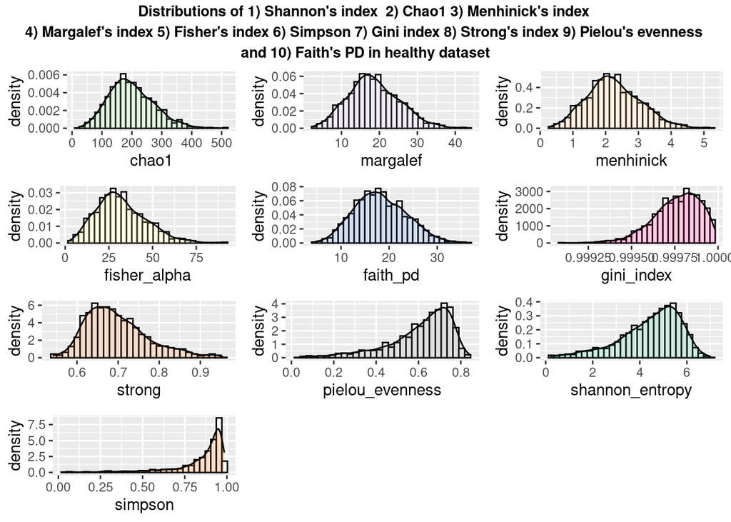

```r
histo <- vector('list', length(metric))

for (i in 1:length(metric)){
  histo[[i]] <- all_healthy %>% ggplot(aes(x = .data[[metric[i]]])) +
    geom_histogram(aes(y=..density..), colour="black", fill="white", bins=30)+
    geom_density(alpha=.2, fill=colors[i]) +
    xlab(label = metric[i]) +
    ylab(label = "density")
}

grid.arrange(histo[[1]], histo[[2]],histo[[3]], histo[[4]],histo[[5]], histo[[6]],histo[[7]], histo[[8]],histo[[9]], histo[[10]], ncol=3, top = textGrob("Distributions of 1) Shannon's index  2) Chao1 3) Menhinick's index \n4) Margalef's index 5) Fisher's index 6) Simpson 7) Gini index 8) Strong's index 9) Pielou's evenness \nand 10) Faith's PD in healthy dataset", gp=gpar(fontsize=10,font=2)))
```

### Testing for normality

Shapiro-Wilk’s method is widely recommended for normality test and it provides better power than K-S. It is based on the correlation between the data and the corresponding normal scores.

```r
pval_sp <- list()
stat_sp <- list()

for (i in 1:length(metric)){
  pval_sp[i] <- shapiro.test(all_healthy[[metric[i]]])[2]
  stat_sp[i] <- shapiro.test(all_healthy[[metric[i]]])[1]
}

stat_sp <- lapply(stat_sp, unname) %>% unlist(stat_sp)
pval_sp <- unlist(pval_sp)

table_saphiro <- data.frame(metric=metric, statistic=stat_sp, p.value=pval_sp)
table_saphiro$p.value <- round(table_saphiro$p.value, digits = 4)

skewness_list <- list()
kurtosis_list <- list()

for(i in 1:length(metric)){
  #calculate skewness
  sk <- skewness(all_healthy[[metric[i]]])
  skewness_list <- append(skewness_list, sk)
  #calculate kurtosis
  kr <- kurtosis(all_healthy[[metric[i]]])
  kurtosis_list <- append(kurtosis_list, kr)
}

table_saphiro$skewness <- unlist(skewness_list)
table_saphiro$kurtosis <- unlist(kurtosis_list)

table_saphiro %>%
  arrange(desc(statistic)) %>%
  flextable() %>%
  add_header_lines(values = "Normality test (Shapiro-Wilk), skewness and kurtosis of different metrics")
```

| Normality test (Shapiro-Wilk), skewness and kurtosis of different metrics metric | Normality test (Shapiro-Wilk), skewness and kurtosis of different metrics statistic | Normality test (Shapiro-Wilk), skewness and kurtosis of different metrics p.value | Normality test (Shapiro-Wilk), skewness and kurtosis of different metrics skewness | Normality test (Shapiro-Wilk), skewness and kurtosis of different metrics kurtosis |
| --- | --- | --- | --- | --- |
| faith_pd | 0.9937791 | 0 | 0.2673681 | -0.215873808 |
| margalef | 0.9915654 | 0 | 0.3456230 | -0.008835332 |
| menhinick | 0.9915654 | 0 | 0.3456230 | -0.008835332 |
| chao1 | 0.9831686 | 0 | 0.5375670 | 0.365618698 |
| fisher_alpha | 0.9742693 | 0 | 0.6494941 | 0.448945228 |
| gini_index | 0.9603465 | 0 | -0.7684431 | 0.621481862 |
| strong | 0.9559614 | 0 | 0.8152890 | 0.493076400 |
| shannon_entropy | 0.9454567 | 0 | -0.8837669 | 0.480453293 |
| pielou_evenness | 0.8938897 | 0 | -1.2674681 | 1.406554965 |
| simpson | 0.7173910 | 0 | -2.2548790 | 5.293303004 |

Normal distribution: * p-value > 0.05 for Shapiro-Wilk’s statistic * skewness = 0 * kurtosis = 3

Consclusion: none of the metrics follow perfect normal distribution. However, Faith PD, Menhinick and Margalef are closest to normality.

## Correlations

Most of the variables in metadata are categorical. Only few variables are numerical. We can calculate Pearson’s correlation coefficient only for two numerical variables. However, we also want to know which categorical factors possibly affect alpha diversity. That’s why we are going to construct linear regression model to retrieve coefficients of determination as measure of the impact of categorical variable on alpha diversity.

### Explore correlations of numerical variables with alhpa metrics

First lets check correlations between alpha diversity metrics:

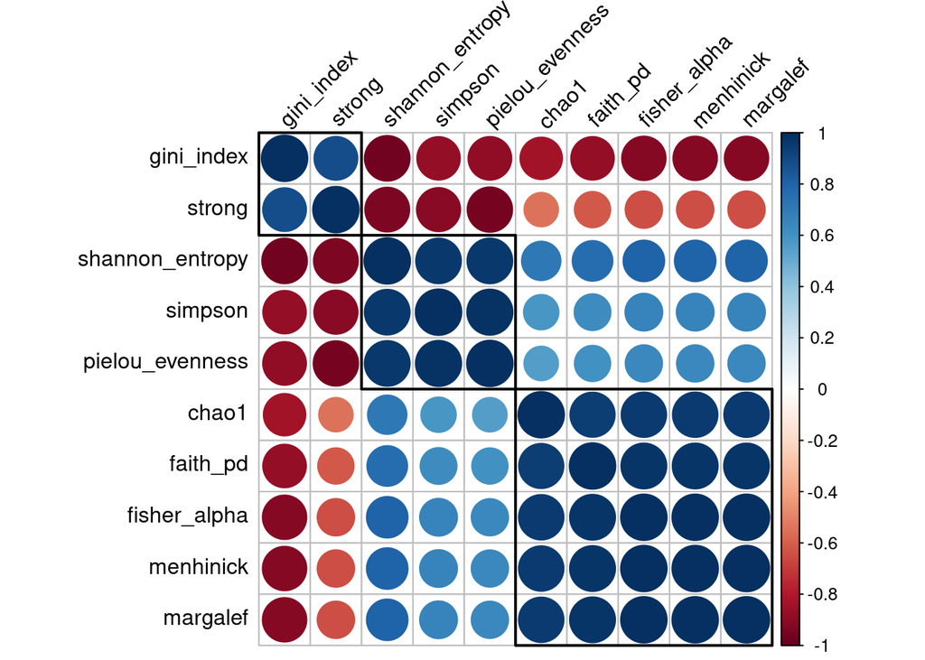

```r
only_metrics <- all_healthy[,2:11]
cor_matrix <- cor(only_metrics, method = "spearman")

#corrplot(cor_matrix, type = "upper", order = "hclust", addrect = 3, tl.col = "black", tl.srt = 45)

corrplot(cor_matrix, order = 'hclust', addrect = 3, tl.col = "black", tl.srt = 45)
```

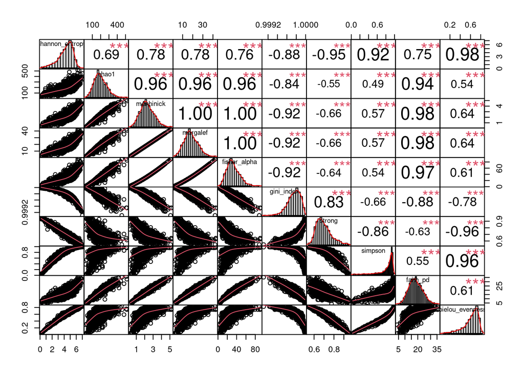

```r
chart.Correlation(only_metrics, histogram=TRUE, pch=19)
```

From this we can see that most of the alpha metrics are positively correlated except from Gini index and Strong’s dominance index which are positively correlated among themselves and negatively correlated with the rest of the metrics.

We can also see three “blocks” of alpha metrics which are strongly positively correlated - * first: Chao1, Fisher’s, Manhinick’s richness index, Margalef’ richness index and Faith’s phylogenetic diversity, * second: Shannon’s entropy, Simpson’ index and Pielou’s evenness, * third: Gini index and Strong’s dominance index.